# ML Algorihms

# Gradient Descent an optimization algorithm

# Gradient descent is a optimization algorithm used in linear regression to find the best fit line tohe data. It works by #gradually by adjusting the line’s slope and intercept to reduce the difference between actual and predicted values.

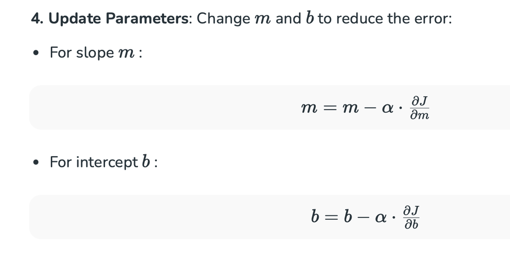

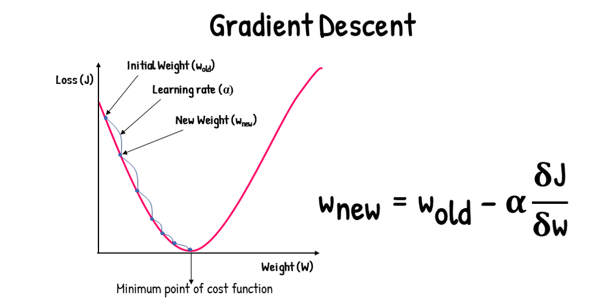

```python
from sklearn.datasets import make_regression
X, y = make_regression(n_samples=100, n_features=1, noise=15, random_state=42)

print("Feature values (X):\n", X[:5])   # first 5 feature values
print("\nTarget values (y):\n", y[:5])  # first 5 target values
```

```
Feature values (X):
 [[ 0.93128012]
 [ 0.08704707]
 [-1.05771093]
 [ 0.31424733]
 [-0.47917424]]

Target values (y):
 [ 56.73356571 -16.91462544 -30.30257886   9.23159976 -16.60693589]
```

```python
data = pd.DataFrame({'X': X.flatten(), 'y': y})
print(data.head())
```

```
          X          y
0  0.931280  56.733566
1  0.087047 -16.914625
2 -1.057711 -30.302579
3  0.314247   9.231600
4 -0.479174 -16.606936
```

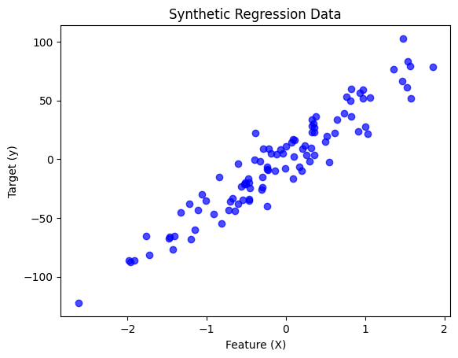

```python
plt.scatter(X, y, color='blue', alpha=0.7)
plt.title("Synthetic Regression Data")
plt.xlabel("Feature (X)")
plt.ylabel("Target (y)")
plt.show()
```

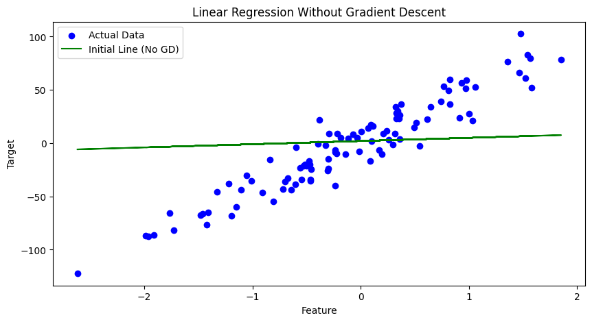

```python
#scikit-learn’s make_regression() function to generate synthetic regression data
#n_samples=100	Generate 100 data points (rows)
# n_features=1	Each data point has one input feature (X has 1 column)
# noise=15	Add random noise (variance) to make the data less perfect — more realistic
# random_state=42	Fix the random seed so you get the same data every time (for reproducibility)

X, y = make_regression(n_samples=100, n_features=1, noise=15, random_state=42)
y = y.reshape(-1, 1)
m = X.shape[0]

# X → a 2D NumPy array of shape (100, 1) → input feature(s)
# X.shape  # (100, 1)
# y.shape  # (100,)
# But sometimes you want it as a 2D column vector, especially if you’re doing matrix operations
# reshape(-1, 1) converts it to shape (100, 1) (100 rows, 1 column).
# The -1 just means “infer this dimension automatically.”
# m = X.shape[0] --->This extracts the number of samples (rows) from X.Since X.shape = (100, 1),
# Then X.shape[0] = 100.

#y → a 1D NumPy array of shape (100,) → target values (output)

X_b = np.c_[np.ones((m, 1)), X]

theta = np.array([[2.0], [3.0]])

plt.figure(figsize=(10, 5))
plt.scatter(X, y, color="blue", label="Actual Data")
plt.plot(X, X_b.dot(theta), color="green", label="Initial Line (No GD)")
plt.xlabel("Feature")
plt.ylabel("Target")
plt.title("Linear Regression Without Gradient Descent")
plt.legend()
plt.show()
```

Now we will apply gradient descent to improve the model and optimize these parameters.

```
learning_rate = 0.1, n_iterations = 100: Set the learning rate and number of iterations for gradient descent to run respectively.
gradients = (2 / m) * X_b.T.dot(y_pred - y): Finding gradients of the cost function with respect to parameters. this equation is the derivative of the Mean Squared Error cost function
theta -= learning_rate * gradients: Updating parameters by moving opposite to the gradient direction.
```

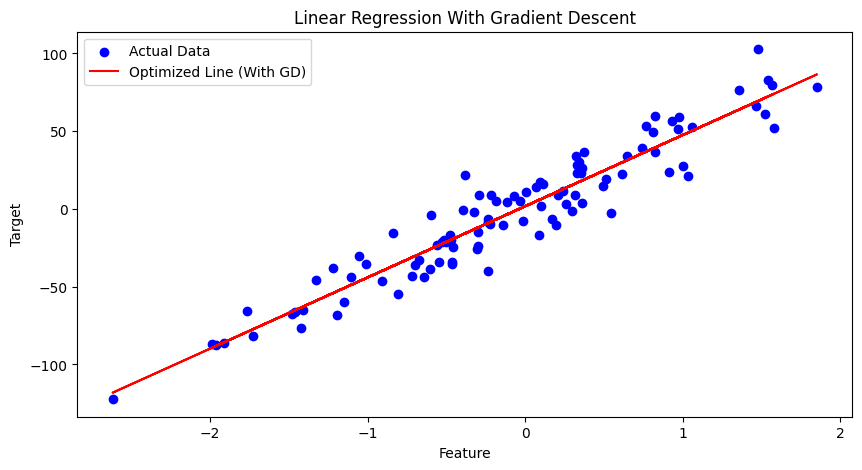

```python
learning_rate = 0.1
n_iterations = 100

for _ in range(n_iterations):

    y_pred = X_b.dot(theta)

    gradients = (2 / m) * X_b.T.dot(y_pred - y)
    #y_pred - y → the error (difference between predicted and true values).
    #X_b.T.dot(y_pred - y) → In NumPy, A.dot(B) means multiply matrices A and B, T. also is Transpose
    #(2 / m) → scaling factor from the derivative of MSE (where m = number of samples).

    theta -= learning_rate * gradients

plt.figure(figsize=(10, 5))
plt.scatter(X, y, color="blue", label="Actual Data")
plt.plot(X, X_b.dot(theta), color="red", label="Optimized Line (With GD)")
plt.xlabel("Feature")
plt.ylabel("Target")
plt.title("Linear Regression With Gradient Descent")
plt.legend()
plt.show()
```

```python
# Abocve code is manually implement the GD but using libraries is below code:
```

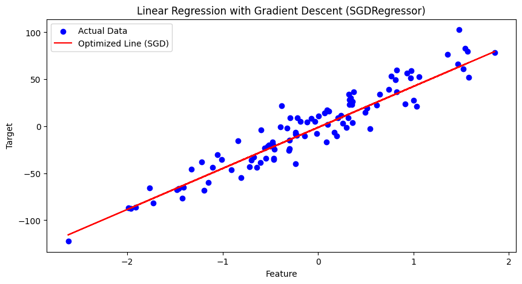

```
Intercept: -1.2507619559770846
Coefficient: 43.642885203960375
```

```python
#import numpy as np
#import matplotlib.pyplot as plt
from sklearn.datasets import make_regression
from sklearn.linear_model import SGDRegressor

# Generate synthetic regression data
X, y = make_regression(n_samples=100, n_features=1, noise=15, random_state=42)

# Initialize SGD regressor
sgd_reg = SGDRegressor(max_iter=1000, learning_rate="constant", eta0=0.1, penalty=None, random_state=42)

#SGDRegressor runs gradient descent for you.
#max_iter = number of iterations.
#learning_rate="constant" with eta0=0.1 specifies a fixed learning rate.
# penalty=None → no regularization (just pure gradient descent).
#It learns the intercept and coefficient automatically.

# Train model
sgd_reg.fit(X, y)

# Predictions
y_pred = sgd_reg.predict(X)

# Plot results
plt.figure(figsize=(10, 5))
plt.scatter(X, y, color="blue", label="Actual Data")
plt.plot(X, y_pred, color="red", label="Optimized Line (SGD)")
plt.xlabel("Feature")
plt.ylabel("Target")
plt.title("Linear Regression with Gradient Descent (SGDRegressor)")
plt.legend()
plt.show()

# Print learned parameters
print("Intercept:", sgd_reg.intercept_[0])
print("Coefficient:", sgd_reg.coef_[0])
```

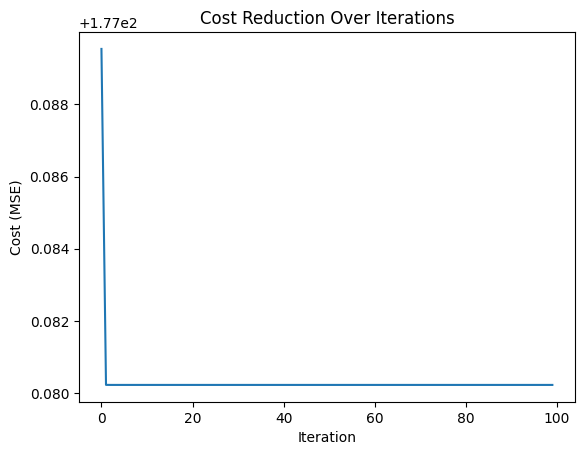

```python
# Scikit-learn’s SGDRegressor doesn’t give cost history by default,
# but you can loop manually with partial_fit to track cost over iterations.

sgd_reg = SGDRegressor(max_iter=1, learning_rate="constant", eta0=0.1, penalty=None, random_state=42, warm_start=True)
cost_history = []

for i in range(100):
    sgd_reg.partial_fit(X, y)
    y_pred = sgd_reg.predict(X)
    cost = np.mean((y_pred - y) ** 2)
    cost_history.append(cost)

plt.plot(cost_history)
plt.xlabel("Iteration")
plt.ylabel("Cost (MSE)")
plt.title("Cost Reduction Over Iterations")
plt.show()
```

# Logistic Regression

Logistic Regression is a supervised machine learning algorithm used for classification problems. Unlike linear regression which predicts continuous values it predicts the probability that an input belongs to a specific class. It is used for binary classification where the output can be one of two possible categories such as Yes/No, True/False or 0/1. It uses sigmoid function to convert inputs into a probability value between 0 and 1.

```
Independent observations: Each data point is assumed to be independent of the others means there should be no correlation or dependence between the input samples.
Binary dependent variables: It takes the assumption that the dependent variable must be binary, means it can take only two values. For more than two categories SoftMax functions are used.
Linearity relationship between independent variables and log odds: The model assumes a linear relationship between the independent variables and the log odds of the dependent variable which means the predictors affect the log odds in a linear way.
No outliers: The dataset should not contain extreme outliers as they can distort the estimation of the logistic regression coefficients.
Large sample size: It requires a sufficiently large sample size to produce reliable and stable results.
```

Understanding Sigmoid Function

1. The sigmoid function is a important part of logistic regression which is used to convert the raw output of the model into a probability value between 0 and 1.
2. This function takes any real number and maps it into the range 0 to 1 forming an "S" shaped curve called the sigmoid curve or logistic curve. Because probabilities must lie between 0 and 1, the sigmoid function is perfect for this purpose.
3. In logistic regression, we use a threshold value usually 0.5 to decide the class label.

   If the sigmoid output is same or above the threshold, the input is classified as Class 1. If it is below the threshold, the input is classified as Class 0.

```python
from sklearn.datasets import load_breast_cancer
from sklearn.linear_model import LogisticRegression
from sklearn.model_selection import train_test_split
from sklearn.metrics import accuracy_score

X, y = load_breast_cancer(return_X_y=True)

X_train, X_test, y_train, y_test = train_test_split(X, y, test_size=0.20, random_state=23)

clf = LogisticRegression(max_iter=10000, random_state=0)
clf.fit(X_train, y_train)

acc = accuracy_score(y_test, clf.predict(X_test)) * 100
print(f"Logistic Regression model accuracy: {acc:.2f}%")
```

```
Logistic Regression model accuracy: 96.49%
```

A cost function is a mathematical function that calculates the difference between the target actual values (ground truth) and the values predicted by the model. A function that assesses a machine learning model's performance also referred to as a loss function or objective function.

Plotting this specific error function against the linear regression model's weight parameters results in a convex shape. This convexity is important because it allows the Gradient DescentAlgorithm to be used to optimize the function. Using this algorithm, we can locate the global minima on the graph and modify the model's weights to systematically lower the error. In essence, it's a means of optimizing the model to raise its accuracy in making predictions.

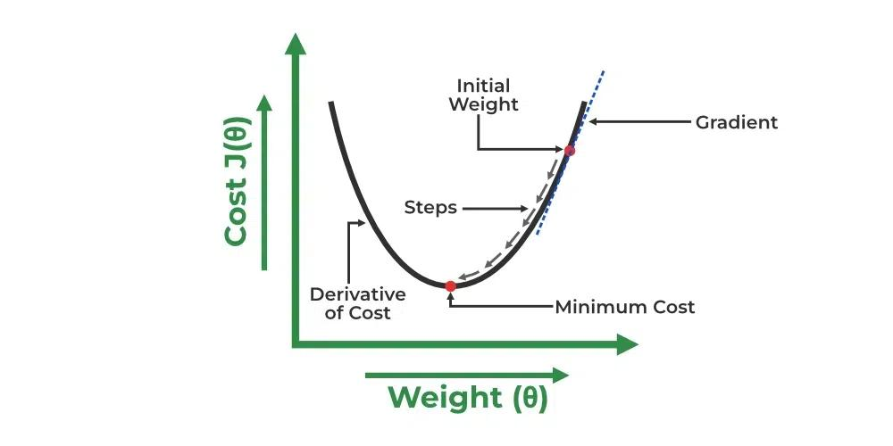

```python
# ---------- Data ----------
data = {
    "pass_id": np.arange(0, 1000),
    "survive": np.random.choice(['yes', 'no'], size=1000),
    "pclass": np.random.choice(['top', 'ave', 'poor'], size=1000),
    "age": np.random.randint(10, 80, size=1000),
    "name": ["Mo_" + str(i) for i in range(0, 1000)],
    "sex": np.random.choice(['M', 'F'], size=1000)
}
df = pd.DataFrame(data)
df.head()
```

|  | pass_id | survive | pclass | age | name | sex |
| --- | --- | --- | --- | --- | --- | --- |
| 0 | 0 | yes | poor | 57 | Mo_0 | M |
| 1 | 1 | no | ave | 16 | Mo_1 | F |
| 2 | 2 | yes | poor | 56 | Mo_2 | F |
| 3 | 3 | yes | top | 47 | Mo_3 | F |
| 4 | 4 | no | top | 11 | Mo_4 | M |

```python
# ---------- Preprocessing ----------
pclass_mapping = {'poor': 0, 'ave': 1, 'top': 2}
df['pclass'] = df['pclass'].map(pclass_mapping)

from sklearn.preprocessing import LabelEncoder
encod_cols = ['sex', 'survive']
for col in encod_cols:
    le = LabelEncoder()
    df[col] = le.fit_transform(df[col])

df.drop(columns='name', inplace=True)
```

```python
# ---------- Split ----------
from sklearn.model_selection import train_test_split
x = df.drop('survive', axis=1)
y = df['survive']
X_train, X_test, y_train, y_test = train_test_split(x, y, test_size=0.2, random_state=123)
```

```python
from sklearn.metrics import accuracy_score, confusion_matrix, classification_report
```

```python
# ---------- 1. Batch Gradient Descent (LogisticRegression) ----------
from sklearn.linear_model import LogisticRegression
lr_model = LogisticRegression(solver='lbfgs', max_iter=1000)
lr_model.fit(X_train, y_train)
pred_lr = lr_model.predict(X_test)
acc_lr = accuracy_score(y_test, pred_lr)
print("Batch Gradient Descent (LogisticRegression):")
print("Accuracy:", acc_lr)
```

```
Batch Gradient Descent (LogisticRegression):
Accuracy: 0.51
```

```python
# ---------- 2. Stochastic Gradient Descent (SGDClassifier) ----------
from sklearn.linear_model import SGDClassifier

# SGD with multiple epochs, learning rate, and stochastic updates
sgd_model = SGDClassifier(loss='log_loss', penalty='l2', learning_rate='optimal', max_iter=1000, random_state=123)

# This will internally use stochastic updates (1 sample at a time) efficiently
sgd_model.fit(X_train, y_train)

pred_sgd = sgd_model.predict(X_test)
acc_sgd = accuracy_score(y_test, pred_sgd)

print("✅ Stochastic Gradient Descent (SGD - fast version):")
print("Accuracy:", acc_sgd)
print("Confusion Matrix:\n", confusion_matrix(y_test, pred_sgd))
print("Classification Report:\n", classification_report(y_test, pred_sgd))
```

```
✅ Stochastic Gradient Descent (SGD - fast version):
Accuracy: 0.51
Confusion Matrix:
 [[45 64]
 [34 57]]
Classification Report:
               precision    recall  f1-score   support

           0       0.57      0.41      0.48       109
           1       0.47      0.63      0.54        91

    accuracy                           0.51       200
   macro avg       0.52      0.52      0.51       200
weighted avg       0.52      0.51      0.51       200
```

```python
# ---------- 3. Mini-Batch Gradient Descent (Custom partial_fit loop) ----------
mini_model = SGDClassifier(loss='log_loss', penalty='l2', learning_rate='optimal', max_iter=1, random_state=123, warm_start=True)
batch_size = 32
for _ in range(100):  # epochs
    for i in range(0, X_train.shape[0], batch_size):
        X_batch = X_train.iloc[i:i+batch_size]
        y_batch = y_train.iloc[i:i+batch_size]
        mini_model.partial_fit(X_batch, y_batch, classes=np.array([0, 1]))
pred_mini = mini_model.predict(X_test)
acc_mini = accuracy_score(y_test, pred_mini)
print("Mini-Batch Gradient Descent (Batch size = 32):")
print("Accuracy:", acc_mini)
```

```
Mini-Batch Gradient Descent (Batch size = 32):
Accuracy: 0.545
```

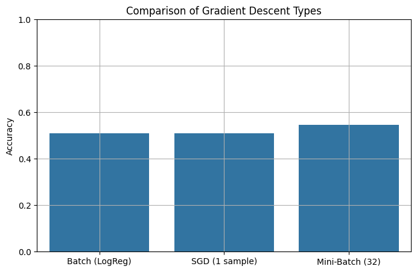

```python
# ---------- Plot Accuracy Comparison ----------
labels = ['Batch (LogReg)', 'SGD (1 sample)', 'Mini-Batch (32)']
accuracies = [acc_lr, acc_sgd, acc_mini]

plt.figure(figsize=(8,5))
sns.barplot(x=labels, y=accuracies)
plt.ylabel('Accuracy')
plt.title('Comparison of Gradient Descent Types')
plt.ylim(0, 1)
plt.grid(True)
plt.show()
```

```python
from sklearn.metrics import accuracy_score, confusion_matrix, classification_report

# ---------- 1. Batch Gradient Descent (LogisticRegression) ----------
print("✅ Batch Gradient Descent (LogisticRegression):")
print("Accuracy:", acc_lr)
print("Confusion Matrix:\n", confusion_matrix(y_test, pred_lr))
print("Classification Report:\n", classification_report(y_test, pred_lr))

# ---------- 2. Stochastic Gradient Descent (SGDClassifier) ----------
print("\n✅ Stochastic Gradient Descent (SGD - 1 sample):")
print("Accuracy:", acc_sgd)
print("Confusion Matrix:\n", confusion_matrix(y_test, pred_sgd))
print("Classification Report:\n", classification_report(y_test, pred_sgd))

# ---------- 3. Mini-Batch Gradient Descent (batch size = 32) ----------
print("\n✅ Mini-Batch Gradient Descent (Batch size = 32):")
print("Accuracy:", acc_mini)
print("Confusion Matrix:\n", confusion_matrix(y_test, pred_mini))
print("Classification Report:\n", classification_report(y_test, pred_mini))
```

```
✅ Batch Gradient Descent (LogisticRegression):
Accuracy: 0.51
Confusion Matrix:
 [[53 56]
 [42 49]]
Classification Report:
               precision    recall  f1-score   support

           0       0.56      0.49      0.52       109
           1       0.47      0.54      0.50        91

    accuracy                           0.51       200
   macro avg       0.51      0.51      0.51       200
weighted avg       0.52      0.51      0.51       200


✅ Stochastic Gradient Descent (SGD - 1 sample):
Accuracy: 0.51
Confusion Matrix:
 [[45 64]
 [34 57]]
Classification Report:
               precision    recall  f1-score   support

           0       0.57      0.41      0.48       109
           1       0.47      0.63      0.54        91

    accuracy                           0.51       200
   macro avg       0.52      0.52      0.51       200
weighted avg       0.52      0.51      0.51       200


✅ Mini-Batch Gradient Descent (Batch size = 32):
Accuracy: 0.545
Confusion Matrix:
 [[109   0]
 [ 91   0]]
Classification Report:
               precision    recall  f1-score   support

           0       0.55      1.00      0.71       109
           1       0.00      0.00      0.00        91

    accuracy                           0.55       200
   macro avg       0.27      0.50      0.35       200
weighted avg       0.30      0.55      0.38       200
```